# Athlete Success Survey

Mr.Slizen

10/24/2021

This report need *tidyverse* package in order to compile properly

##Data inport Let’s define some functions for data import

```r
import_data <- function(ext) {
  list.files(path = '../data/', pattern = paste0('*.',ext), full.names = T) %>%
               map_df(~read_csv(., show_col_types = F))
}


import_problems <- function(ext) {
  list.files(path = '../data/', pattern = paste0('*.',ext), full.names = T) %>%
    map_df(~problems(read_csv(., show_col_types = F)))
}
```

## importing data

We have multiple csv with results and features of athletes in different olympic games. Let’s try to import it and merge into single dataframe

```r
sport_data <- import_data('csv')
str(sport_data)
```

```
## spec_tbl_df [271,115 × 15] (S3: spec_tbl_df/tbl_df/tbl/data.frame)
##  $ ID    : num [1:271115] 1 2 3 4 5 5 5 5 5 5 ...
##  $ Name  : chr [1:271115] "A Dijiang" "A Lamusi" "Gunnar Nielsen Aaby" "Edgar Lindenau Aabye" ...
##  $ Sex   : chr [1:271115] "M" "M" "M" "M" ...
##  $ Age   : num [1:271115] 24 23 24 34 21 21 25 25 27 27 ...
##  $ Height: num [1:271115] 180 170 NA NA 185 185 185 185 185 185 ...
##  $ Weight: num [1:271115] 80 60 NA NA 82 82 82 82 82 82 ...
##  $ Team  : chr [1:271115] "China" "China" "Denmark" "Denmark/Sweden" ...
##  $ NOC   : chr [1:271115] "CHN" "CHN" "DEN" "DEN" ...
##  $ Games : chr [1:271115] "1992 Summer" "2012 Summer" "1920 Summer" "1900 Summer" ...
##  $ Year  : num [1:271115] 1992 2012 1920 1900 1988 ...
##  $ Season: chr [1:271115] "Summer" "Summer" "Summer" "Summer" ...
##  $ City  : chr [1:271115] "Barcelona" "London" "Antwerpen" "Paris" ...
##  $ Sport : chr [1:271115] "Basketball" "Judo" "Football" "Tug-Of-War" ...
##  $ Event : chr [1:271115] "Basketball Men's Basketball" "Judo Men's Extra-Lightweight" "Football Men's Football" "Tug-Of-War Men's Tug-Of-War" ...
##  $ Medal : chr [1:271115] NA NA NA "Gold" ...
##  - attr(*, "spec")=
##   .. cols(
##   ..   ID = col_double(),
##   ..   Name = col_character(),
##   ..   Sex = col_character(),
##   ..   Age = col_double(),
##   ..   Height = col_double(),
##   ..   Weight = col_double(),
##   ..   Team = col_character(),
##   ..   NOC = col_character(),
##   ..   Games = col_character(),
##   ..   Year = col_double(),
##   ..   Season = col_character(),
##   ..   City = col_character(),
##   ..   Sport = col_character(),
##   ..   Event = col_character(),
##   ..   Medal = col_character()
##   .. )
##  - attr(*, "problems")=<externalptr>
```

We have a dataframe but we found some problems. What are those?

```r
import_problems('csv')
```

```
## # A tibble: 9 × 5
##     row   col expected   actual     file
##   <int> <int> <chr>      <chr>      <chr>
## 1 22837     9 15 columns 9 columns  /home/wha/inst_bio/STA_R/BI_Stat_2021/olymp…
## 2 22588     9 15 columns 9 columns  /home/wha/inst_bio/STA_R/BI_Stat_2021/olymp…
## 3 22559     8 15 columns 8 columns  /home/wha/inst_bio/STA_R/BI_Stat_2021/olymp…
## 4 22661     8 15 columns 8 columns  /home/wha/inst_bio/STA_R/BI_Stat_2021/olymp…
## 5 22603    14 15 columns 14 columns /home/wha/inst_bio/STA_R/BI_Stat_2021/olymp…
## 6 22644     6 15 columns 6 columns  /home/wha/inst_bio/STA_R/BI_Stat_2021/olymp…
## 7 22783    13 15 columns 13 columns /home/wha/inst_bio/STA_R/BI_Stat_2021/olymp…
## 8 22411     2 15 columns 2 columns  /home/wha/inst_bio/STA_R/BI_Stat_2021/olymp…
## 9 22465     2 15 columns 2 columns  /home/wha/inst_bio/STA_R/BI_Stat_2021/olymp…
```

Looks like we have a number of lines with wrong number of columns. Visual inspection shows, that last lines in some of original csv are partial and in that way useless. Let’s redifine functions for import.

```r
read_prop_csv <- function(path){if (nrow(problems(read_csv(path,show_col_types = F)))) {
  read_csv(path, show_col_types = F) %>% head(.,-1)
} else {
  read_csv(path, show_col_types = F)
}}

import_data <- function(ext) {
  list.files(path = '../data/', pattern = paste0('*.',ext), full.names = T) %>%
    map_df(~read_prop_csv(.))
}
```

…and import data once more:

```r
sport_data <- import_data('csv')
```

[output not shown]

Let’s brush it even more. A couple of rows has “G” in a Sex column. Visual inspection shows, that both of them are men. WARNING: If dataset us changed, please readjust filters on this step. Also, let’s drop complete duplicates and take - Sex, NOC, Season, Sport, Medal - as factor variables.

```r
sport_data <- mutate(sport_data, Sex = replace(Sex, Sex == "G", "M")) %>%
  distinct(.) %>%
  mutate(across(c(Sex, NOC, Season, Sport), as.factor )) %>%
  mutate(Medal=factor(Medal,levels = c('Gold',"Silver",'Bronze')))
```

## Tasks

**3)** So, what are minimal ages for Male and Females un 1992 Olympics?

```r
filter(sport_data, Year == 1992) %>%
  group_by(Sex) %>%
  summarize(min_age = min(Age, na.rm = T))
```

```
## # A tibble: 2 × 2
##   Sex   min_age
##   <fct>   <dbl>
## 1 F          12
## 2 M          11
```

Wow! **12 for females and 11 for males**. So young.. **4)** What are mean and std for Height in both genders? As long as many athletes have participated in multiple Olympics and Events let’s keep only one value for each ID.

```r
distinct(sport_data,ID,.keep_all = T) %>%
  group_by(Sex) %>%
  summarize(mean_height=mean(Height, na.rm = T), sd=sd(Height, na.rm = T))
```

```
## # A tibble: 2 × 3
##   Sex   mean_height    sd
##   <fct>       <dbl> <dbl>
## 1 F            169.  8.51
## 2 M            179.  9.46
```

**for Females mean = 168.9320, sd = 8.5117108423 and for Males mean = 179.4397, sd = 9.462296**

Nothing surprising here men are higher than women. But athletes are a bit higher than common average persons of respective gender.

**5)** But, what are the same statistics for Female tennisists in 2000? The same way, we will drop duplicates by ID

```r
filter(sport_data, Year == 2000, Sex == 'F', Sport =='Tennis') %>%
  distinct(ID, .keep_all = T) %>%
  summarize(mean_height=mean(Height, na.rm = T), sd=sd(Height, na.rm = T))
```

```
## # A tibble: 1 × 2
##   mean_height    sd
##         <dbl> <dbl>
## 1        172.  6.56
```

**mean = 171.8068, sd = 6.563322** Hm, okay. **6)** What sport practices the biggest athlete of 2006 Olympics?

```r
filter(sport_data, Year == 2006) %>%
  filter(Weight == max(Weight, na.rm = T)) %>%
  select(Sport)
```

```
## # A tibble: 1 × 1
##   Sport
##   <fct>
## 1 Skeleton
```

It was **skeleton** **7)** How many Golds won women between 1980 and 2020

```r
filter(sport_data, Sex == 'F', Medal == "Gold", between(Year, 1980,2020)) %>%
  nrow()
```

```
## [1] 2959
```

**2959 gold medals** - quite a lot! Intrestingly same result for man is 4283. Not sure why so. **8)** What is th number of Olympic games John Aalberg have participated in?

```r
filter(sport_data, Name == 'John Aalberg') %>%
  distinct(Year) %>%
  nrow()
```

```
## [1] 2
```

**Only 2 times!** Poor thing

**9)** Which age groups are the most and the least abundant on the 2008 Olympics? Age groups are [10-15), [15-25), [25-35), [35-45), [45-55), [55-65), [65-70). Note, that we have NA values in Age column.

```r
filter(sport_data, Year == 2008) %>%
  drop_na(Age) %>%
  distinct(.,ID,.keep_all = T) %>%
  mutate(ints = cut(Age, breaks=c(10,15,25,35,45,55,65,70), right = F)) %>%
  group_by(ints) %>%
  summarize(number=n()) %>%
  arrange(number) %>% slice(c(1,nrow(.)))
```

```
## # A tibble: 2 × 2
##   ints    number
##   <fct>    <int>
## 1 [65,70)      1
## 2 [25,35)   5382
```

First line is the **smallest age group - 65-70 with only 1** brave old person Second line is the **biggest age group - 25-35 with 5382 persons**

**10)**How did changed number of sports in 2002 Olympics in comparison with 1994?

```r
filter(sport_data, Year %in% c(2002, 1994)) %>%
  group_by(Year) %>%
  distinct(Sport) %>%
  summarize(n_sports=n())
```

```
## # A tibble: 2 × 2
##    Year n_sports
##   <dbl>    <int>
## 1  1994       12
## 2  2002       15
```

```r
sport_data %>%
  drop_na(Team,Season,Medal) %>%
  group_by(Season, Medal, Team) %>%
  summarize(number_of_medals=n(),.groups = "drop_last") %>%
  top_n(3)  %>%
  arrange(desc(number_of_medals),.by_group = T)
```

```
## # A tibble: 18 × 4
## # Groups:   Season, Medal [6]
##    Season Medal  Team          number_of_medals
##    <fct>  <fct>  <chr>                    <int>
##  1 Summer Gold   United States             2333
##  2 Summer Gold   Soviet Union               830
##  3 Summer Gold   Germany                    564
##  4 Summer Silver United States             1241
##  5 Summer Silver Soviet Union               635
##  6 Summer Silver Great Britain              576
##  7 Summer Bronze United States             1112
##  8 Summer Bronze Germany                    610
##  9 Summer Bronze Soviet Union               596
## 10 Winter Gold   Canada                     289
## 11 Winter Gold   Soviet Union               228
## 12 Winter Gold   Norway                     151
## 13 Winter Silver United States              271
## 14 Winter Silver Canada                     189
## 15 Winter Silver Norway                     165
## 16 Winter Bronze Finland                    215
## 17 Winter Bronze Sweden                     177
## 18 Winter Bronze Norway                     127
```

Here we have it. 18 rows of requested data. **12)** Let’s add variable Height_z_scores with standartized Heights of athletes

```r
mean_height <- distinct(sport_data,ID, .keep_all = T) %>%
  pull(Height) %>% mean(.,na.rm = T)
sd_height <- distinct(sport_data,ID, .keep_all = T) %>%
  pull(Height) %>% sd(.,na.rm = T)
sport_data <- mutate(sport_data, Height_z_scores = (Height - mean_height)/sd_height)
```

**13)** mim-max normalization Let’s inspect if or top and bottom values are okay

```r
top_n(sport_data,5,Height)
```

```
## # A tibble: 8 × 16
##       ID Name    Sex     Age Height Weight Team   NOC   Games  Year Season City
##    <dbl> <chr>   <fct> <dbl>  <dbl>  <dbl> <chr>  <fct> <chr> <dbl> <fct>  <chr>
## 1  16639 Tommy … M        20    223    102 Unite… USA   1972…  1972 Summer Muni…
## 2  23549 Kirsty… F        28    340     64 Zimba… ZIM   2012…  2012 Summer Lond…
## 3 104059 Arvyda… M        23    223    122 Sovie… URS   1988…  1988 Summer Seoul
## 4 104059 Arvyda… M        27    223    122 Lithu… LTU   1992…  1992 Summer Barc…
## 5 104059 Arvyda… M        31    223    122 Lithu… LTU   1996…  1996 Summer Atla…
## 6 132627 Yao Mi… M        20    226    141 China  CHN   2000…  2000 Summer Sydn…
## 7 132627 Yao Mi… M        23    226    141 China  CHN   2004…  2004 Summer Athi…
## 8 132627 Yao Mi… M        27    226    141 China  CHN   2008…  2008 Summer Beij…
## # … with 4 more variables: Sport <fct>, Event <chr>, Medal <fct>,
## #   Height_z_scores <dbl>
```

```r
top_n(sport_data,-5,Height)
```

```
## # A tibble: 7 × 16
##      ID Name     Sex     Age Height Weight Team   NOC   Games  Year Season City
##   <dbl> <chr>    <fct> <dbl>  <dbl>  <dbl> <chr>  <fct> <chr> <dbl> <fct>  <chr>
## 1 15150 Rosario… F        15    127     42 Mexico MEX   1968…  1968 Summer Mexi…
## 2 15150 Rosario… F        15    127     42 Mexico MEX   1968…  1968 Summer Mexi…
## 3 15150 Rosario… F        15    127     42 Mexico MEX   1968…  1968 Summer Mexi…
## 4 15150 Rosario… F        15    127     42 Mexico MEX   1968…  1968 Summer Mexi…
## 5 15150 Rosario… F        15    127     42 Mexico MEX   1968…  1968 Summer Mexi…
## 6 15150 Rosario… F        15    127     42 Mexico MEX   1968…  1968 Summer Mexi…
## 7 82769 Lyton L… M        25    127     62 Malawi MAW   1988…  1988 Summer Seoul
## # … with 4 more variables: Sport <fct>, Event <chr>, Medal <fct>,
## #   Height_z_scores <dbl>
```

```r
sport_data <- filter(sport_data, is.na(Height) | Height != 340) %>%
  mutate(Height_min_max_scaled=
                        ((Height-min(Height,na.rm = T))/(max(Height,na.rm = T)-min(Height,na.rm = T))))
```

**14)** Compare Height, Weight and Age between men and women i Winter Olympics

```r
men <- group_by(sport_data, Sex) %>%
  distinct(ID,.keep_all = T) %>%
  filter(Season == 'Winter',Sex == 'M')
women <- group_by(sport_data, Sex) %>%
  distinct(ID,.keep_all = T) %>%
  filter(Season == 'Winter',Sex == 'F')
```

Let’s have a look at Height

```r
t.test(men$Height,women$Height)
```

```
##
##  Welch Two Sample t-test
##
## data:  men$Height and women$Height
## t = 108.88, df = 8704.3, p-value < 2.2e-16
## alternative hypothesis: true difference in means is not equal to 0
## 95 percent confidence interval:
##  12.53564 12.99529
## sample estimates:
## mean of x mean of y
##  178.8494  166.0839
```

Let’s have a look at Weight

```r
t.test(men$Weight,women$Weight)
```

```
##
##  Welch Two Sample t-test
##
## data:  men$Weight and women$Weight
## t = 113.06, df = 10831, p-value < 2.2e-16
## alternative hypothesis: true difference in means is not equal to 0
## 95 percent confidence interval:
##  17.69529 18.31969
## sample estimates:
## mean of x mean of y
##  77.74444  59.73695
```

Let’s have a look at Age

```r
t.test(men$Age,women$Age)
```

```
##
##  Welch Two Sample t-test
##
## data:  men$Age and women$Age
## t = 30.865, df = 9595.9, p-value < 2.2e-16
## alternative hypothesis: true difference in means is not equal to 0
## 95 percent confidence interval:
##  2.068826 2.349431
## sample estimates:
## mean of x mean of y
##  24.24393  22.03480
```

**15)** Are Team and Medals variables independent? In order to check it we will perform Chi-square test. For this test will filter teams that have at least 5 of each type of medals.

```r
teams <- sport_data %>%
  count(Team,Medal) %>%
  filter(!is.na(Medal), n > 5) %>% ungroup %>%
  group_by(Team) %>% filter(n()>2) %>% distinct(Team) %>%
  pull(Team)
all_medals <- sport_data %>% drop_na(Medal) %>% filter(Team %in% teams)
```

There are 77 teams that passed filtering and 3 kinds of medals. I Makes 152 degrees of freedom. What does the Chi say?

```r
chisq.test(all_medals$Team, all_medals$Medal)
```

```
##
##  Pearson's Chi-squared test
##
## data:  all_medals$Team and all_medals$Medal
## X-squared = 1686.8, df = 152, p-value < 2.2e-16
```

With grate certainty we can say that not all teams are equal and some prefer medals od certain kind over others. **X-squared = 1686.8, df = 152 with p-value < 2.2e-16**

## Additional

Not sure what tests can help analyze this but I found something intresting. If you compare Weight distribution between summer and winter sports you can see something intresting.

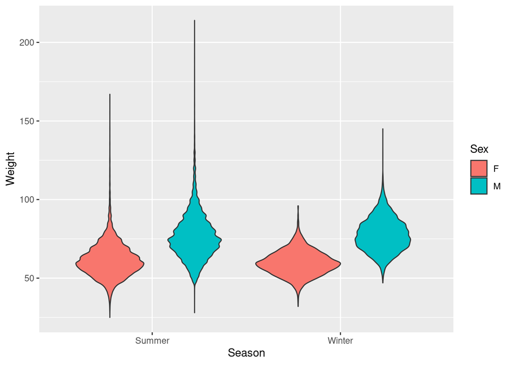

```
##  [1] Speed Skating             Cross Country Skiing
##  [3] Ice Hockey                Biathlon
##  [5] Alpine Skiing             Luge
##  [7] Bobsleigh                 Figure Skating
##  [9] Nordic Combined           Freestyle Skiing
## [11] Ski Jumping               Curling
## [13] Snowboarding              Short Track Speed Skating
## [15] Skeleton                  Military Ski Patrol
## [17] Alpinism
## 66 Levels: Aeronautics Alpine Skiing Alpinism Archery ... Wrestling
```

Looks like there are no winter martial arts. What about summer?

```
##  [1] Basketball            Judo                  Football
##  [4] Tug-Of-War            Athletics             Swimming
##  [7] Badminton             Sailing               Gymnastics
## [10] Art Competitions      Handball              Weightlifting
## [13] Wrestling             Water Polo            Hockey
## [16] Rowing                Fencing               Equestrianism
## [19] Shooting              Boxing                Taekwondo
## [22] Cycling               Diving                Canoeing
## [25] Tennis                Modern Pentathlon     Golf
## [28] Softball              Archery               Volleyball
## [31] Synchronized Swimming Table Tennis          Baseball
## [34] Rhythmic Gymnastics   Rugby Sevens          Trampolining
## [37] Beach Volleyball      Triathlon             Rugby
## [40] Lacrosse              Polo                  Cricket
## [43] Ice Hockey            Racquets              Motorboating
## [46] Croquet               Figure Skating        Jeu De Paume
## [49] Roque                 Basque Pelota         Alpinism
## [52] Aeronautics
## 66 Levels: Aeronautics Alpine Skiing Alpinism Archery ... Wrestling
```

Here we have Judo, Boxing, Wrestling,TTaekwondo Let’s have a look at specific summer sports and their distribution comparing to all other sports

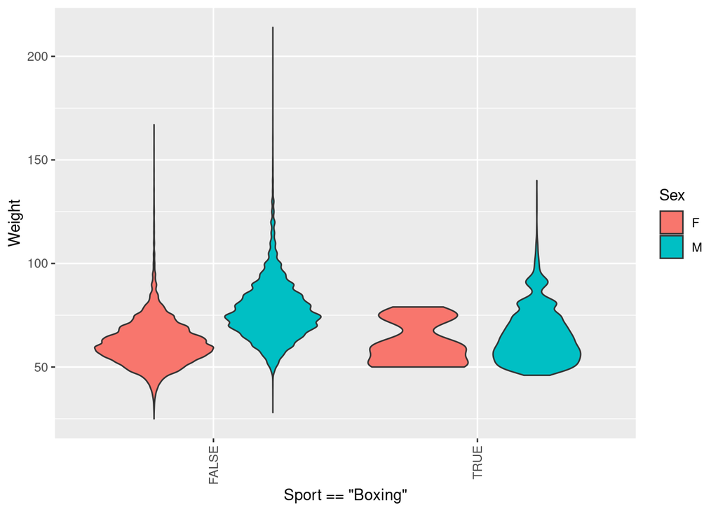

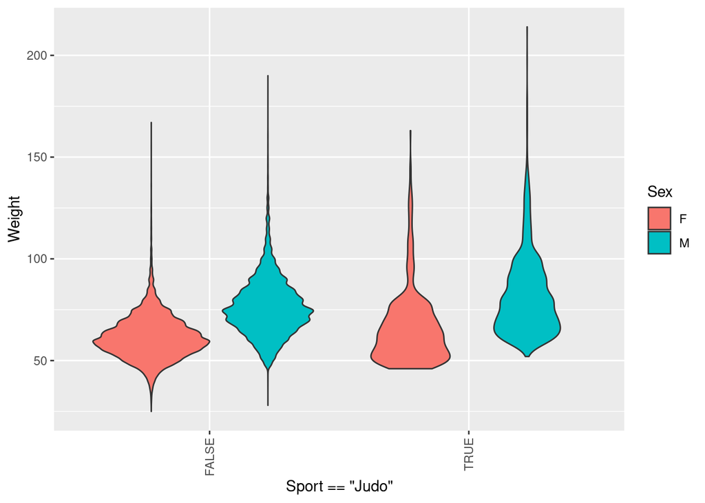

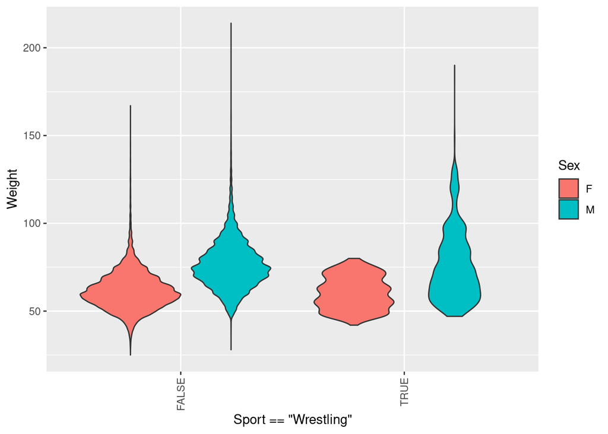

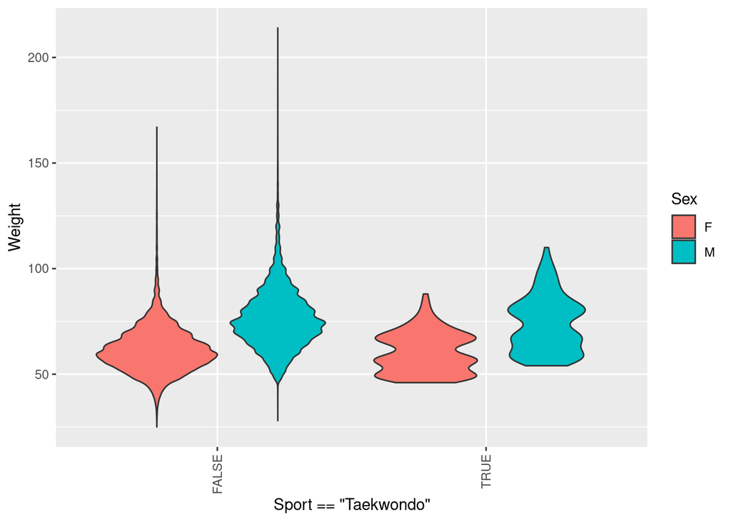

There is clear that martial arts have noticeable weight categories, but it looks like it is different in different sports and not as sharp as one can expect. That way it can’t really explain “ribbed” distribution of weights on Summer Olympics. Would be nice to figure out some statistical methods to answer such questions…